# Contributions to Canadian Political Entities 2024

Gagandeep Dolla

2024-11-07

# Introduction

This report provides an analysis of contributions to Canadian political entities in 2024, using data from Elections Canada. The focus is on trends, major contributors, and comparative statistics. Updated weekly, the data helps identify patterns in funding and political support across provinces. **Data download date:** November 5, 2024.

## Data Source

All data was obtained from [Elections Canada](https://www.elections.ca), updated weekly and sourced on the specified download date. Contributions data is as reviewed by Elections Canada for accuracy.

# Load Data

```r
# Load your data
contributions <- read.csv("~/Downloads/PoliticalFinance/od_cntrbtn_de_e.csv")

# Convert dates and filter for 2024
contributions$Contribution.Received.date <- as.Date(contributions$Contribution.Received.date, format = "%Y-%m-%d")
contributions_2024 <- contributions %>% filter(year(Contribution.Received.date) == 2024)
```

# Overview of Contributions in 2024

The following overview provides key metrics on contributions made in 2024:

```r
# Summary statistics for 2024 with formatted amounts
summary_stats <- contributions_2024 %>%
  summarize(
    Total_Monetary_Contributions = sum(Monetary.amount, na.rm = TRUE),
    Total_Non_Monetary_Contributions = sum(Non.Monetary.amount, na.rm = TRUE),
    Average_Contribution = mean(Monetary.amount, na.rm = TRUE),
    Median_Contribution = median(Monetary.amount, na.rm = TRUE)
  )

# Format numbers with commas and units in thousands/millions
summary_stats <- summary_stats %>%
  mutate(
    Total_Monetary_Contributions = paste0(formatC(Total_Monetary_Contributions, big.mark = ",", format = "f", digits = 0), " (", round(Total_Monetary_Contributions / 1e6, 2), "M)"),
    Total_Non_Monetary_Contributions = paste0(formatC(Total_Non_Monetary_Contributions, big.mark = ",", format = "f", digits = 0), " (", round(Total_Non_Monetary_Contributions / 1e3, 2), "K)"),
    Average_Contribution = paste0(formatC(Average_Contribution, big.mark = ",", format = "f", digits = 0), " (", round(Average_Contribution / 1e3, 2), "K)"),
    Median_Contribution = paste0(formatC(Median_Contribution, big.mark = ",", format = "f", digits = 0), " (", round(Median_Contribution / 1e3, 2), "K)")
  )

# Convert summary_stats to long format for kable
summary_stats_long <- summary_stats %>%
  pivot_longer(cols = everything(), names_to = "Metric", values_to = "Value")

# Display the summary statistics table
knitr::kable(summary_stats_long, col.names = c("Metric", "Value"), caption = "Summary of Contributions in 2024")
```

Summary of Contributions in 2024

| Metric | Value |
| --- | --- |
| Total_Monetary_Contributions | 29,549,596 (29.55M) |
| Total_Non_Monetary_Contributions | 6,249 (6.25K) |
| Average_Contribution | 305 (0.3K) |
| Median_Contribution | 144 (0.14K) |

# Monthly Trends in Contributions

This section shows the monthly trend of contributions in 2024. It helps visualize funding peaks and patterns across the year.

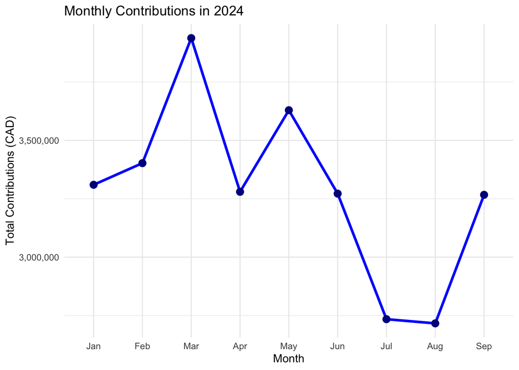

```r
# Monthly contributions (only up to September)
monthly_trends <- contributions_2024 %>%
  filter(month(Contribution.Received.date) <= 9) %>%
  mutate(month = month(Contribution.Received.date, label = TRUE)) %>%
  group_by(month) %>%
  summarize(total_amount = sum(Monetary.amount, na.rm = TRUE))

# Plot with formatted y-axis labels
ggplot(monthly_trends, aes(x = month, y = total_amount)) +
  geom_line(group = 1, color = "blue", size = 1.2) +
  geom_point(size = 3, color = "darkblue") +
  labs(title = "Monthly Contributions in 2024", x = "Month", y = "Total Contributions (CAD)") +
  scale_y_continuous(labels = scales::comma) +
  theme_minimal()
```

# Contributions by Province

Mapping contributions by province provides a visual distribution of where the funding is concentrated across Canada.

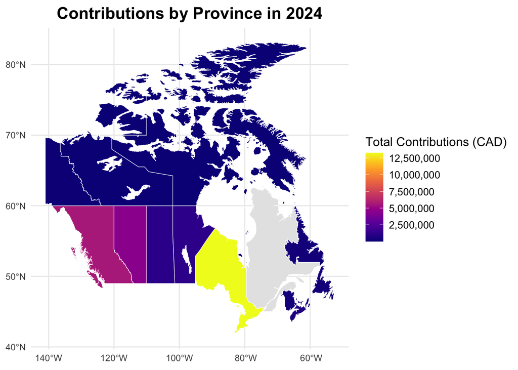

```r
# Load Canada provinces shapefile using rnaturalearth
canada_map <- rnaturalearth::ne_states(country = "Canada", returnclass = "sf")

# Summarize contributions by province
province_contributions <- contributions_2024 %>%
  group_by(Contributor.Province) %>%
  summarize(total_monetary = sum(Monetary.amount, na.rm = TRUE))

# Adjust province names in `province_contributions` to match `canada_map`
province_contributions <- province_contributions %>%
  mutate(Contributor.Province = recode(Contributor.Province,
                                       "ON" = "Ontario",
                                       "QC" = "Quebec",
                                       "BC" = "British Columbia",
                                       "AB" = "Alberta",
                                       "MB" = "Manitoba",
                                       "SK" = "Saskatchewan",
                                       "NS" = "Nova Scotia",
                                       "NB" = "New Brunswick",
                                       "PE" = "Prince Edward Island",
                                       "NL" = "Newfoundland and Labrador",
                                       "YT" = "Yukon",
                                       "NT" = "Northwest Territories",
                                       "NU" = "Nunavut"))

# Join contributions data with Canada map
province_data <- canada_map %>%
  left_join(province_contributions, by = c("name" = "Contributor.Province"))

# Plot the map with fill for contributions
ggplot(province_data) +
  geom_sf(aes(fill = total_monetary), color = "white", size = 0.3) +
  scale_fill_viridis(option = "plasma", name = "Total Contributions (CAD)", labels = scales::comma, na.value = "grey90") +
  labs(title = "Contributions by Province in 2024") +
  theme_minimal() +
  theme(
    plot.title = element_text(hjust = 0.5, size = 16, face = "bold"),
    legend.position = "right",
    legend.title = element_text(size = 12),
    legend.text = element_text(size = 10)
  )
```

# Top 10 Contributors

Identifying the top 10 contributors provides insight into the most significant funders.

```r
# Filter out self-donations, aggregate by contributor
top_contributors <- contributions_2024 %>%
  filter(Contributor.name != Recipient) %>%
  group_by(Contributor.name, Contributor.City) %>%
  summarize(total_contribution = sum(Monetary.amount, na.rm = TRUE), .groups = "drop") %>%
  arrange(desc(total_contribution)) %>%
  head(10) %>%
  mutate(
    total_contribution = paste0(formatC(total_contribution, big.mark = ",", format = "f", digits = 0), " (", round(total_contribution / 1e3, 2), "K)")
  )

# Display the table
knitr::kable(top_contributors, col.names = c("Contributor", "City", "Total Contribution (CAD)"), caption = "Top 10 Contributors in 2024 (Excluding Self-Donations)")
```

Top 10 Contributors in 2024 (Excluding Self-Donations)

| Contributor | City | Total Contribution (CAD) |
| --- | --- | --- |
| Pepperell, Penelope E | Toronto | 3,820 (3.82K) |
| Johal, Gurinder Singh | Hudson | 3,725 (3.72K) |
| Lavigne, Marc | Saint-Charles-Sur-Richelieu | 3,475 (3.48K) |
| Baldwin, Douglas D | CALGARY | 3,450 (3.45K) |
| Eansor, Kenneth J | TECUMSEH | 3,450 (3.45K) |
| Heffernan, Clare | Vancouver | 3,450 (3.45K) |
| Rennie, Bob | Vancouver | 3,450 (3.45K) |
| Gold, Robert | HAMPSTEAD | 3,375 (3.38K) |
| Grant, John D | TORONTO | 3,350 (3.35K) |
| Hussain, Safdar | Brampton | 3,125 (3.13K) |

# Contributions by Political Party

This chart shows the total contributions received by each political party, giving an overview of where financial support is concentrated.

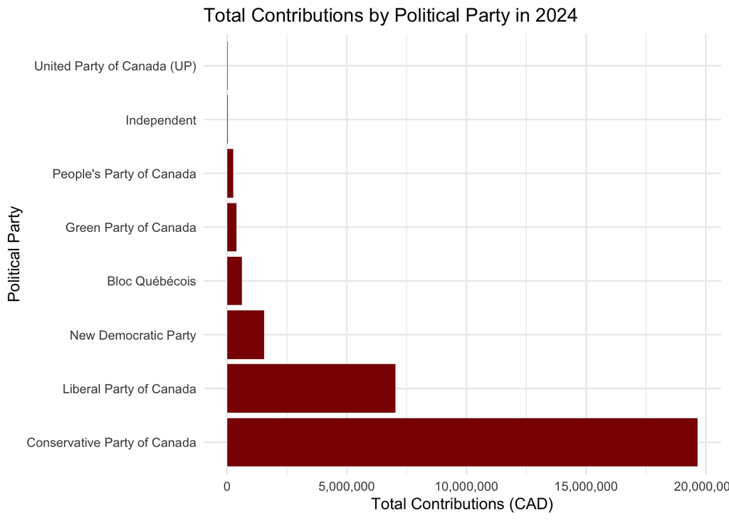

```r
# Contributions by political party
party_contributions <- contributions_2024 %>%
  group_by(Political.Party.of.Recipient) %>%
  summarize(total_monetary = sum(Monetary.amount, na.rm = TRUE))

# Plot with formatted y-axis
ggplot(party_contributions, aes(x = reorder(Political.Party.of.Recipient, -total_monetary), y = total_monetary)) +
  geom_col(fill = "darkred") +
  coord_flip() +
  scale_y_continuous(labels = scales::comma) +
  labs(title = "Total Contributions by Political Party in 2024", x = "Political Party", y = "Total Contributions (CAD)") +
  theme_minimal()
```